# Quantitative metrics for evaluating registration performance

Sai Srikanth Lakkimsetty

July, 2022

# 1 Introduction

Automated and unsupervised registration, by definition, does not need user’s input for landmarks / annotations in the images. This also affects the way we evaluate the quality of the registration. If landmarks were present, we could develop a method around the relative distances between landmarks ante- and post-registration. If regions were annotated, we could apply Hausdorff distance to gather insights as to how well the method performed.

However, these are not possible with **automated and unsupervised** registration. Furthermore, these questions remain,

- Did the registration perform satisfactorily globally?
- Were local deformations resolved?
- Did the registration induce any folds in the “canvas”?

There is no **single** metric that answers all of the above questions. However, a set of metrics could be developed and tuned to answer specific questions. Some of them are below.

- Sørensen-Dice coef. - Dice
- Jaccard’s similarity index
- Normalized gradient field - Modersitzki & Haber
- Mutual information - Viola & Wells
- Normalized MI - Studholme et. al.
- Correlation ratio - Roche et. al.
- Woods function - Woods et. al.
- Dense vector field jacobian

The essential idea is to start with various image similarity measuring metrics and adapt them to apply for image registration evaluation. Dice coefficient, Jaccard’s index, mutual information, normalized MI, and the correlation ratio provide insight into the global registration. Normalized gradient field deals with the local registration quality. Dense vector field jacobian computes and visualizes the artefacts induced by the registration process.

# 2 Sørensen-Dice Similarity Coefficient<sup>[[1](https://support.brainvoyager.com/images/documents/Available_Tools/Available_Scripts/python/ImageRegistrationEvaluationViaDiceCoefficientInBV_v02.pdf)]</sup>

The Dice coefficient, `D` is essentially the percentage of area that is overlapping between the optical and MS image.

$A$, $B$ are the images represented on the coordinate grid. $\cap$ represents the overlapped area between two images.

$$D = \frac{2 \mid A \cap B \mid}{\mid A \mid + \mid B \mid}$$

Pros:

- `D` is very simple to compute and report

Cons:

- `D` is so simple that it only speaks to global (mis-) alignment.
- Very **wrong** registrations can actually have close-to-100% Dice coefficient. For example consider the setting of affine transformation where the rotation is 90$^\circ$. The overall overlap would still be significantly high but the registration task has failed. So, reporting just (or optimizing for) `D` is not a good idea.

## 2.1 Implementation details

Overlaps are computed using binary masks generated from, * Fiji (ImageJ) for optical images. * Cardinal for MS images.

MS image’s binary mask is just resampled with transformation to generate transformed moving image’s mask.

```r
diceCoef <- function(mask1, mask2) {
    # Check for all masks to be of identical size.
    # [!TODO] check

    composite <- ((mask1 + mask2) / 2) - 0.005
    composite <- ifelse(composite > 0.5, 1, 0)
    aINTb <- mean(composite)
    a <- mean(mask1)
    b <- mean(mask2)
    (2 * aINTb) / (a + b)
}
```

## 2.2 Results

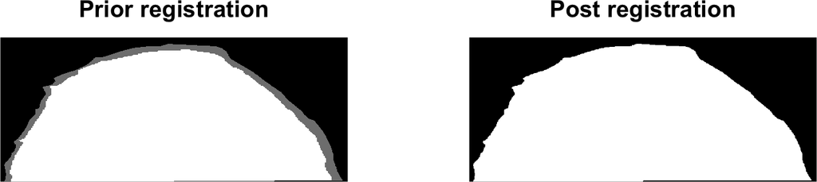

```r
D_prior <- diceCoef(mse_mask_u, opt_mask)
D_post <- diceCoef(opt_mask, .mse_mask_itk_tx_arr)

overlay_prior <- as.Image(opt_mask) * 0.5 + as.Image(mse_mask_u) * 0.5
overlay_post <- as.Image(opt_mask) * 0.5 + as.Image(.mse_mask_itk_tx_arr) * 0.5

plots <- list(overlay_prior, overlay_post)
coregPlotOverlays(plots,
                  global_title="Mask overlays before and after registration",
                  quartz=FALSE, aspect_ratio=(.nX/.nY), plot_config=c(1,2))
```

```r
# Console only code
# coregPlotOverlays(plots,
#                   global_title="Mask overlays before and after registration",
#                   quartz=TRUE, aspect_ratio=(.nX/.nY), plot_config=c(1,2))
```

Dice coefficient before registration is 0.955.  
Dice coefficient after registration is 0.996.

# 3 Normalized Mutual Information (NMI)

Normalized mutual information is a modified version of MI. It solves the MI’s problem of unboundedness.

Below, $H$ is Shannon’s entropy of an image and $A$, $B$ are the image intensities represented on the coordinate grid.

$$MI = H(A) + H(B) - H(A,B)$$
$$NMI = \frac{H(A) + H(B)}{H(A,B)}$$
$$NMI = \frac{MI}{H(A,B)} + 1$$

## 3.1 Implementation details

- Use exisiting implementation from R scripts (MS thesis)
- Use histograms (binning method) to estimate $H$.

# 4 Normalized Cross Correlation (NCC)

Just your garden variety correlation. $A$, $B$ are the image intensities represented on the coordinate grid, and $i$, $j$ are indices pointing to the pixels of the image.

$$NCC = \frac{\sum_{i=1}^{M}\sum_{j=1}^{N} (A(i,j) - \bar{A})(B(i,j) - \bar{B})}{\sqrt{\sum_{i=1}^{M}\sum_{j=1}^{N}(A(i,j) - \bar{A})^2 \sum_{i=1}^{M}\sum_{j=1}^{N}(B(i,j) - \bar{B})^2}}$$

## 4.1 Implementation details

# 5 Displacement field jacobian determinant

The Jacobian, $J$’s determinant is used to measure the folding of a transformation. *Folding* is an artefact of the registration process wherein a location of the moving image is displaced beyond its neighbor *in that direction*. In other words, the image is made to fold onto itself. Folding is more common during more aggressive registration methods where smoothing or regularization is avoided.

The Jacobian is expressed as a matrix of partial derivatives of components (displacements) with respect to the spatial coordinate system.

$$det(J(A,B)) =
\begin{vmatrix}
\frac{\partial{i}}{\partial{x}} & \frac{\partial{j}}{\partial{x}} \\
\frac{\partial{i}}{\partial{y}} & \frac{\partial{j}}{\partial{y}}
\end{vmatrix}$$